# COVID-19｜城乡 × 年龄 × 时间

第一轮分析 · 2020–2023 · 地区视角 · 2026-11-23

**总体差异不大，仍可以有研究意义。**这次要区分：差多少、是否有统计证据、差异集中在哪些年龄和时期。以下是实际数据结果，推断仍属探索性。

## 1 🧭 这次完成了什么

| 部分 | 已完成 |
| --- | --- |
| 数据核查 | 400地区 × 209周 × 7年龄；列出分母缺失和分类变更 |
| A 总体差异 | 粗率与年龄标准化率；6组两两比较；绝对与相对尺度 |
| B 年龄 | 人口构成、分年龄差异、直接年龄交互检验 |
| C 时间 | 全部周趋势、W1–W5和其余时期、直接时期交互检验 |
| D 年龄＋时间 | 直接检验年龄交互是否随时期变化 |
| 核查 | 地区整组bootstrap 1999次；多重比较校正；独立计算验证 |

主分析使用四年分母完整的**383个地区**，每个地区权重相同，固定使用2023年城乡分类。17个分母不完整地区另列清单，并在可用数据敏感性检查中使用。

## 2 📊 总体：统一年龄构成后，差异仍存在

下面比较的是**平均每周标准化报告发病率**。1＝独立大城市；2＝城市型县；3＝有聚集特征的乡村县；4＝稀疏乡村县。差值为前者减后者；比值为前者除以后者。

| 比较 | 绝对差值 | 逐项95%区间 | 比值 | 差值校正p | 比值校正p |
| --- | --- | --- | --- | --- | --- |
| 1 对 2 | -13.5 | -19.2 至 -7.7 | 0.940 | <0.001 | <0.001 |
| 1 对 3 | -23.3 | -30.1 至 -16.6 | 0.901 | <0.001 | <0.001 |
| 1 对 4 | -22.0 | -28.8 至 -15.2 | 0.906 | <0.001 | <0.001 |
| 2 对 3 | -9.9 | -15.9 至 -3.8 | 0.958 | 0.091 | 0.087 |
| 2 对 4 | -8.5 | -14.7 至 -2.4 | 0.963 | 0.312 | 0.307 |
| 3 对 4 | 1.3 | -5.8 至 8.5 | 1.006 | 1.000 | 1.000 |

大城市对稀疏乡村：粗率差为 **−12.7**，标准化后为 **−22.0** 例/10万人/周，比值约 **0.906**。在这个比较中，统一年龄构成后差距扩大，而非消失。

这不是“年龄造成了多少差异”的因果分解。参考年龄比例来自2021年400地区的RKI推算人口，不是独立官方年龄人口。

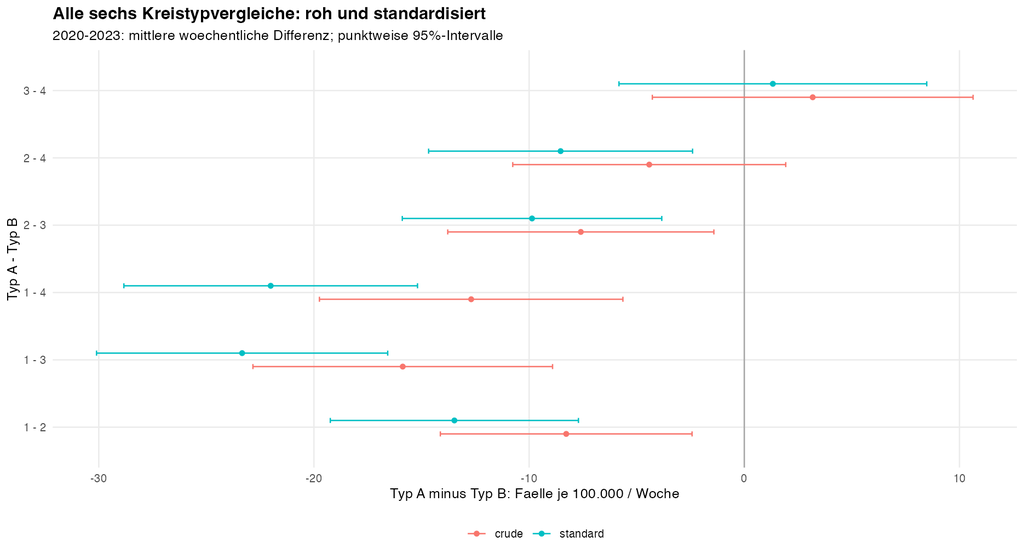

## 3 👥 年龄构成与年龄交互回答不同问题

| 问题 | 含义 |
| --- | --- |
| 年龄构成 | 各类地区里，儿童、成年人、老年人分别占多少？ |
| 年龄标准化 | 如果大家用同样年龄比例，整体差距怎样改变？ |
| 年龄交互 | 儿童的城乡差距，是否与老年人的城乡差距不同？ |

以“大城市 − 稀疏乡村”为例：6–17岁差值约 **−27.7**，70–79岁约 **−3.8**。直接比较这两个差值，得到 **−23.9**（95%区间 −32.5 至 −15.2），绝对尺度年龄交互的Holm校正p<0.001。

**同一例子的相对交互则没有通过该比较族的校正**（比值之比约0.941；校正p约0.102）。所以“年龄是否改变城乡差异”必须说明采用哪种尺度，不能一概而论。

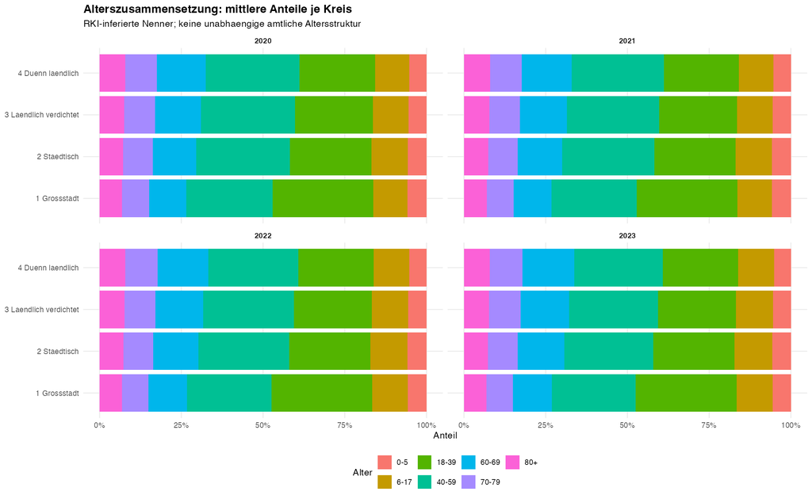

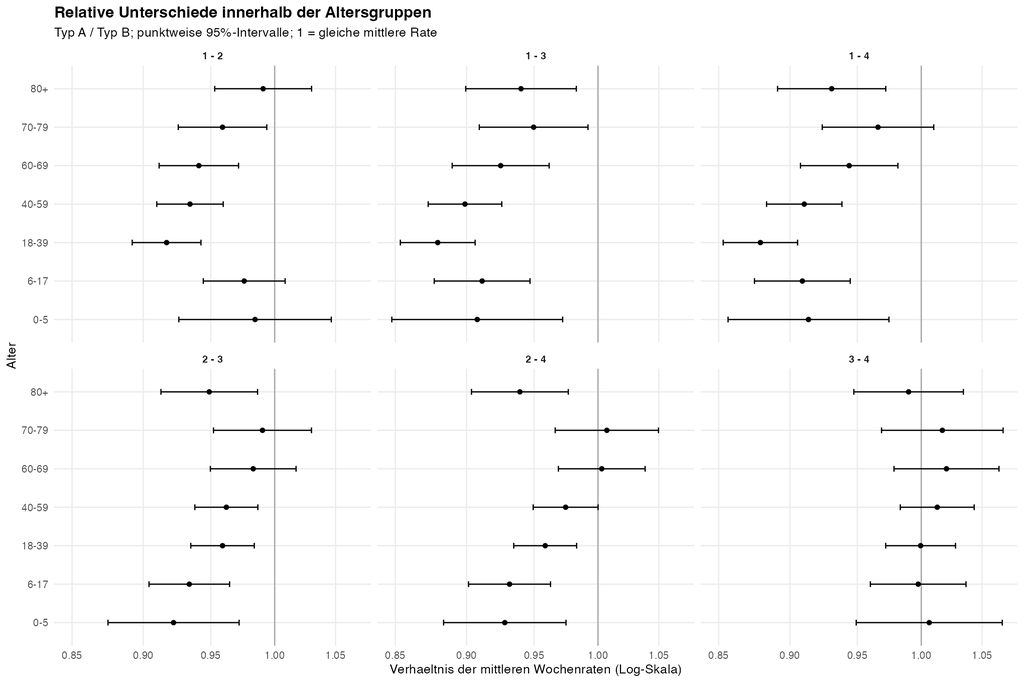

## 4 🕒 时间：差异并非四年始终一样

仍以“大城市 − 稀疏乡村”的标准化率为例：W4平均周差约 **−58.0**，W5约 **−142.7**，W5之后整个长时期平均约 **−3.6**。这些是预定义时期均值，不能替代每周曲线。

**不能据此直接说“W5显著大于W4”。**两时期差值的直接比较在本次大量时期比较的Holm校正后没有足够证据（校正p＝1）。这里的1是多重校正结果，不表示两时期完全相同。

W1–W5沿用并核对RKI表1。P0为W1之前；G1/G2是波次间隔；PostW5是2022年第22周至2023年末的观察段，**不是一个新波次**。后续应结合周曲线和外部划分进一步研究这段长时期。

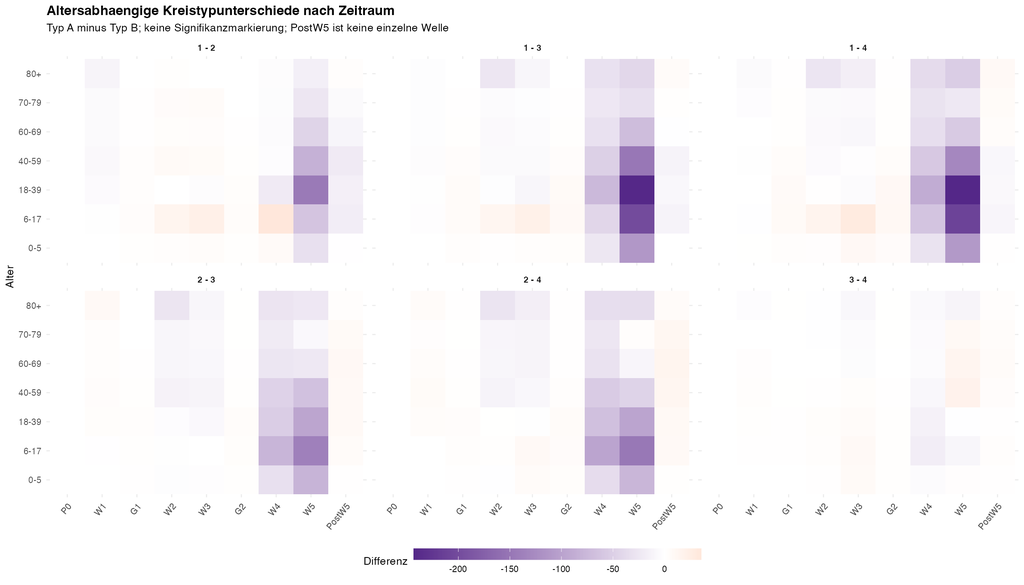

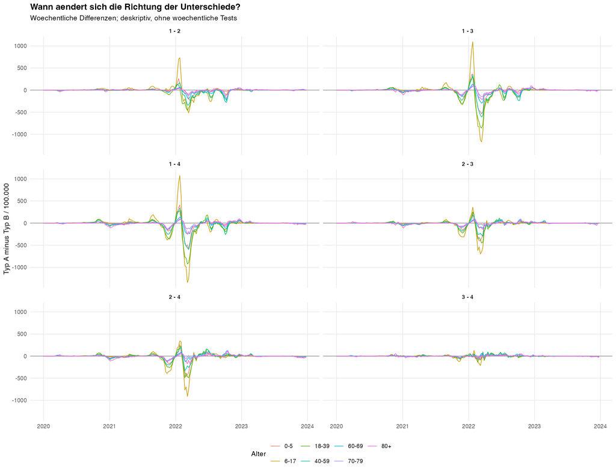

## 5 🔍 哪些判断较稳，哪些仍需谨慎

| 检查 | 本轮发现／限制 |
| --- | --- |
| 资料完整性 | 排除17地区可能限制代表性；缺失没有填零。 |
| 纳入每周可用地区 | 固定分类下，各类型标准化率的全时期均值变化不足1例/10万人/周；个别周变化最高约44.1，不能忽略局部差异。 |
| 分类变更 | 仅改用年度分类时，全时期均值变化不足0.1；个别周约3.2。 |
| 另一套年龄权重 | 已计算地区年龄比例等权的标准化结果；在结果表中标为standard_equal。 |
| 不确定性 | 同地区的时间和年龄关联得到保留；跨地区空间关联未建模，区间可能偏窄。 |
| 统计证据 | 图中区间为逐项95%区间，判断用表中Holm校正p；未显著不等于证明相同。 |
| 零病例 | 早期P0的部分相对比较不稳定，区间和检验留空并标记，不用伪病例凑比值。 |
| 解释范围 | 是报告发病率关联；没有控制通勤、收入、检测等因素，不能做因果结论。 |

## 6 🗂 在项目里怎么看

脚本：`Scripts/Kreistyp_Alter_Zeit/run_analysis.R`  
核查：`Scripts/Kreistyp_Alter_Zeit/validate_results.R`  
全部图表与CSV：`results/Kreistyp_Alter_Zeit/`  
完整方法：`reports/Kreistyp_Alter_Zeit_Methoden.md`

新分支：**analysis/kreistyp-age-time**。已有脚本、未保存的编辑和旧结果保留。本次已直接在RStudio运行，结果在独立环境 `covid_age_time` 中。

## 7 下一步怎么推进

先一起读“总体差异 → 年龄交互 → 时间变化”三组结果，确定论文的主要比较；如果要更强的解释，再加入地区社会因素及空间相关模型。PostW5内的细分需要有外部依据。本次不是只挑显著结果，也没有把Poisson回归方案当成已经完成的模型。

波次来源：[RKI Epidemiologisches Bulletin 38/2022，表1](https://edoc.rki.de/bitstream/handle/176904/10260/EB-38-2022-Phaseneinteilung.pdf?sequence=1)。数值来自本地分析结果；运行记录和输入校验值随结果保存。